# lab-03

Author

Ellya Gholmieh

## 1.Read the Data

```r
file_path <- "C:/Users/ellya/OneDrive/Desktop/PM566labs/met_all.gz"
met <- data.table::fread(file_path)
```

## 2. Check the dimensions, headers, and footers.

```r
dim(met)
```

```
[1] 2377343      30
```

There are 2,377,343 rows and 30 columns in this data set.

## 3. Take a look at the variables.

```r
str(met)
```

```
Classes 'data.table' and 'data.frame':  2377343 obs. of  30 variables:
 $ USAFID           : int  690150 690150 690150 690150 690150 690150 690150 690150 690150 690150 ...
 $ WBAN             : int  93121 93121 93121 93121 93121 93121 93121 93121 93121 93121 ...
 $ year             : int  2019 2019 2019 2019 2019 2019 2019 2019 2019 2019 ...
 $ month            : int  8 8 8 8 8 8 8 8 8 8 ...
 $ day              : int  1 1 1 1 1 1 1 1 1 1 ...
 $ hour             : int  0 1 2 3 4 5 6 7 8 9 ...
 $ min              : int  56 56 56 56 56 56 56 56 56 56 ...
 $ lat              : num  34.3 34.3 34.3 34.3 34.3 34.3 34.3 34.3 34.3 34.3 ...
 $ lon              : num  -116 -116 -116 -116 -116 ...
 $ elev             : int  696 696 696 696 696 696 696 696 696 696 ...
 $ wind.dir         : int  220 230 230 210 120 NA 320 10 320 350 ...
 $ wind.dir.qc      : chr  "5" "5" "5" "5" ...
 $ wind.type.code   : chr  "N" "N" "N" "N" ...
 $ wind.sp          : num  5.7 8.2 6.7 5.1 2.1 0 1.5 2.1 2.6 1.5 ...
```

[output cut: 17 more lines]

As the objectives of this lab are to find the weather station with the highest elevation and to look at patterns in the time series of its wind speed and temperature, the key variables are USAFID, elev (elevation), wind.sp (wind speed), temp (temperature), year, month, day, and hour.

## 4. Take a closer look at the key variables.

```r
table(met$USAFID)
```

```
690150 720110 720113 720120 720137 720151 720169 720170 720172 720175 720193
   750   2258   2868   1319   2240   2256   2210   2258   1865    865   2208
720198 720202 720254 720257 720258 720261 720263 720265 720266 720267 720268
   779   2243   2238   2253   3127   2257   2080   2247   2244   2231   1824
720269 720271 720272 720273 720274 720275 720276 720277 720278 720279 720282
  2226   1356   2251   2257   1765   2849   2241   2209   2237   2174   2157
720283 720284 720285 720286 720287 720288 720289 720291 720293 720294 720295
  3087   2892   2227   2014   1480   2002   2250   1377   2236   2195   1948
720296 720297 720298 720299 720301 720303 720304 720305 720306 720307 720308
  2254   2223   2160   2197   2245   2257   2255   2258   1027   2255   2241
720309 720311 720312 720313 720314 720315 720316 720317 720318 720319 720320
  1976   2227   2235   2247   2258   2226   2234   2190   2258   2243   2237
720321 720322 720323 720324 720326 720327 720328 720330 720333 720334 720339
  2788   2237   2169   4033   2229   2224   2246   2245    805   1005    430
720340 720342 720343 720344 720345 720346 720347 720348 720351 720353 720354
```

[output cut: 275 more lines]

```r
table(met$year)
```

```
   2019
2377343
```

```r
table(met$month)
```

```
      8
2377343
```

```r
table(met$day)
```

```
    1     2     3     4     5     6     7     8     9    10    11    12    13
75975 75923 76915 76594 76332 76734 77677 77766 75366 75450 76187 75052 76906
   14    15    16    17    18    19    20    21    22    23    24    25    26
77852 76217 78015 78219 79191 76709 75527 75786 78312 77413 76965 76806 79114
   27    28    29    30    31
79789 77059 71712 74931 74849
```

```r
table(met$hour)
```

```
     0      1      2      3      4      5      6      7      8      9     10
 99434  93482  93770  96703 110504 112128 106235 101985 100310 102915 101880
    11     12     13     14     15     16     17     18     19     20     21
100470 103605  97004  96507  97635  94942  94184 100179  94604  94928  96070
    22     23
 94046  93823
```

```r
summary(met$temp)
```

```
   Min. 1st Qu.  Median    Mean 3rd Qu.    Max.    NA's
 -40.00   19.60   23.50   23.59   27.80   56.00   60089
```

```r
summary(met$elev)
```

```
   Min. 1st Qu.  Median    Mean 3rd Qu.    Max.
  -13.0   101.0   252.0   415.8   400.0  9999.0
```

```r
summary(met$wind.sp)
```

```
   Min. 1st Qu.  Median    Mean 3rd Qu.    Max.    NA's
   0.00    0.00    2.10    2.46    3.60   36.00   79693
```

```r
met[met$elev==9999.0, ] <- NA
summary(met$elev)
```

```
   Min. 1st Qu.  Median    Mean 3rd Qu.    Max.    NA's
    -13     101     252     413     400    4113     710
```

### At what elevation is the highest weather station?

```r
tail(met[order(met$elev), ])
```

```
   USAFID  WBAN  year month   day  hour   min   lat   lon  elev wind.dir
    <int> <int> <int> <int> <int> <int> <int> <num> <num> <int>    <int>
1:     NA    NA    NA    NA    NA    NA    NA    NA    NA    NA       NA
2:     NA    NA    NA    NA    NA    NA    NA    NA    NA    NA       NA
3:     NA    NA    NA    NA    NA    NA    NA    NA    NA    NA       NA
4:     NA    NA    NA    NA    NA    NA    NA    NA    NA    NA       NA
5:     NA    NA    NA    NA    NA    NA    NA    NA    NA    NA       NA
6:     NA    NA    NA    NA    NA    NA    NA    NA    NA    NA       NA
   wind.dir.qc wind.type.code wind.sp wind.sp.qc ceiling.ht ceiling.ht.qc
        <char>         <char>   <num>     <char>      <int>         <int>
1:        <NA>           <NA>      NA       <NA>         NA            NA
2:        <NA>           <NA>      NA       <NA>         NA            NA
3:        <NA>           <NA>      NA       <NA>         NA            NA
4:        <NA>           <NA>      NA       <NA>         NA            NA
5:        <NA>           <NA>      NA       <NA>         NA            NA
```

[output cut: 17 more lines]

### How many missing values are there in the wind.sp variable?

```r
summary(met$wind.sp)
```

```
   Min. 1st Qu.  Median    Mean 3rd Qu.    Max.    NA's
   0.00    0.00    2.10    2.46    3.60   36.00   79714
```

## 5. Check the data against an external data source.

### Where was the location for the coldest temperature readings (-17.2C)? Do these seem reasonable in context?

```r
met <- met[met$temp > -40, ]
mettemp <- met[order(met$temp),]
head(mettemp)[,c(1,8:10,24)]
```

```
   USAFID    lat    lon  elev  temp
    <int>  <num>  <num> <int> <num>
1: 722817 38.767 -104.3  1838 -17.2
2: 722817 38.767 -104.3  1838 -17.2
3: 722817 38.767 -104.3  1838 -17.2
4: 722817 38.767 -104.3  1838 -17.2
5: 722817 38.767 -104.3  1838 -17.2
6: 722817 38.767 -104.3  1838 -17.2
```

The location for the coldest temperature readings corresponds to Yoder, Colorado. These readings do not seem reasonable for August considering for the last 14 years, the minimum temperature in August has not gone below 10 degrees Celsius (https://www.worldweatheronline.com/v2/weather-averages.aspx?q=80864)

### Does the range of values for elevation make sense? Why or why not?

```r
met <- met[order(met$elev),]
head(met)[,c(1,8:10,24)]
```

```
   USAFID    lat      lon  elev  temp
    <int>  <num>    <num> <int> <num>
1: 722810 32.829 -115.672   -13  40.0
2: 722810 32.829 -115.672   -13  37.8
3: 722810 32.829 -115.672   -13  35.0
4: 722810 32.829 -115.672   -13  33.9
5: 722810 32.829 -115.672   -13  30.6
6: 722810 32.829 -115.672   -13  43.3
```

```r
tail(met)[,c(1,8:10,24)]
```

```
   USAFID   lat      lon  elev  temp
    <int> <num>    <num> <int> <num>
1: 720385  39.8 -105.766  4113    12
2: 720385  39.8 -105.766  4113    12
3: 720385  39.8 -105.766  4113    13
4: 720385  39.8 -105.766  4113    12
5: 720385  39.8 -105.766  4113    12
6: 720385  39.8 -105.766  4113    12
```

The lowest elevation (-13) corresponds to the Naval Air Facility in Imperial, California. According to AirNav.com, the Naval Air Facility is approximately -13m below sea level. The highest elevation (4113) corresponds to Colorado Mines Peak. However, according to Google maps, the elevation at these coordinates is only 3572m. Thus, the reported maximum elevation is too high and does not make sense.

## 6. Calculate summary statistics

```r
elev1 <- met[which(met$elev == max(met$elev, na.rm = TRUE)), ]
summary(elev1)
```

```
     USAFID            WBAN          year          month        day
 Min.   :720385   Min.   :419   Min.   :2019   Min.   :8   Min.   : 1.0
 1st Qu.:720385   1st Qu.:419   1st Qu.:2019   1st Qu.:8   1st Qu.: 8.0
 Median :720385   Median :419   Median :2019   Median :8   Median :16.0
 Mean   :720385   Mean   :419   Mean   :2019   Mean   :8   Mean   :16.1
 3rd Qu.:720385   3rd Qu.:419   3rd Qu.:2019   3rd Qu.:8   3rd Qu.:24.0
 Max.   :720385   Max.   :419   Max.   :2019   Max.   :8   Max.   :31.0

      hour            min             lat            lon              elev
 Min.   : 0.00   Min.   : 6.00   Min.   :39.8   Min.   :-105.8   Min.   :4113
 1st Qu.: 6.00   1st Qu.:13.00   1st Qu.:39.8   1st Qu.:-105.8   1st Qu.:4113
 Median :12.00   Median :36.00   Median :39.8   Median :-105.8   Median :4113
 Mean   :11.66   Mean   :34.38   Mean   :39.8   Mean   :-105.8   Mean   :4113
 3rd Qu.:18.00   3rd Qu.:53.00   3rd Qu.:39.8   3rd Qu.:-105.8   3rd Qu.:4113
 Max.   :23.00   Max.   :59.00   Max.   :39.8   Max.   :-105.8   Max.   :4113

    wind.dir     wind.dir.qc        wind.type.code        wind.sp
 Min.   : 10.0   Length:2117        Length:2117        Min.   : 0.000
 1st Qu.:250.0   Class :character   Class :character   1st Qu.: 4.100
 Median :300.0   Mode  :character   Mode  :character   Median : 6.700
 Mean   :261.5                                         Mean   : 7.245
 3rd Qu.:310.0                                         3rd Qu.: 9.800
 Max.   :360.0                                         Max.   :21.100
 NA's   :237                                           NA's   :168
  wind.sp.qc          ceiling.ht    ceiling.ht.qc   ceiling.ht.method
 Length:2117        Min.   :   30   Min.   :5.000   Length:2117
 Class :character   1st Qu.: 2591   1st Qu.:5.000   Class :character
 Mode  :character   Median :22000   Median :5.000   Mode  :character
                    Mean   :15145   Mean   :5.008
                    3rd Qu.:22000   3rd Qu.:5.000
                    Max.   :22000   Max.   :9.000
                    NA's   :4
   sky.cond            vis.dist     vis.dist.qc          vis.var
 Length:2117        Min.   :    0   Length:2117        Length:2117
 Class :character   1st Qu.:16093   Class :character   Class :character
 Mode  :character   Median :16093   Mode  :character   Mode  :character
                    Mean   :15913
                    3rd Qu.:16093
                    Max.   :16093
                    NA's   :683
  vis.var.qc             temp         temp.qc            dew.point
 Length:2117        Min.   : 1.00   Length:2117        Min.   :-6.0000
 Class :character   1st Qu.: 6.00   Class :character   1st Qu.: 0.0000
 Mode  :character   Median : 8.00   Mode  :character   Median : 0.0000
                    Mean   : 8.13                      Mean   : 0.8729
                    3rd Qu.:10.00                      3rd Qu.: 2.0000
                    Max.   :15.00                      Max.   : 7.0000

 dew.point.qc         atm.press     atm.press.qc       rh
 Length:2117        Min.   : NA    Min.   :9     Min.   :53.63
 Class :character   1st Qu.: NA    1st Qu.:9     1st Qu.:58.10
 Mode  :character   Median : NA    Median :9     Median :61.39
                    Mean   :NaN    Mean   :9     Mean   :60.62
                    3rd Qu.: NA    3rd Qu.:9     3rd Qu.:61.85
                    Max.   : NA    Max.   :9     Max.   :70.01
                    NA's   :2117
```

```r
cor(elev1$temp, elev1$wind.sp, use="complete")
```

```
[1] -0.09373843
```

```r
cor(elev1$temp, elev1$hour, use="complete")
```

```
[1] 0.4397261
```

```r
cor(elev1$wind.sp, elev1$day, use="complete")
```

```
[1] 0.3643079
```

```r
cor(elev1$wind.sp, elev1$hour, use="complete")
```

```
[1] 0.08807315
```

```r
cor(elev1$temp, elev1$day, use="complete")
```

```
[1] -0.003857766
```

## 7. Exploratory graphs

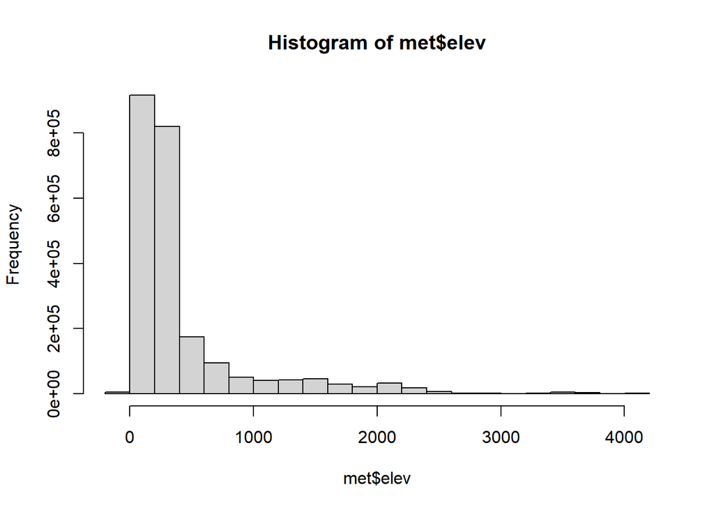

```r
hist(met$elev)
```

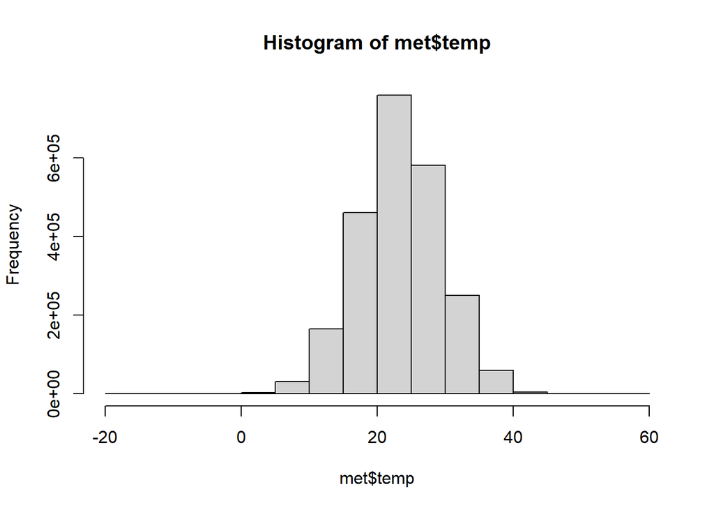

```r
hist(met$temp)
```

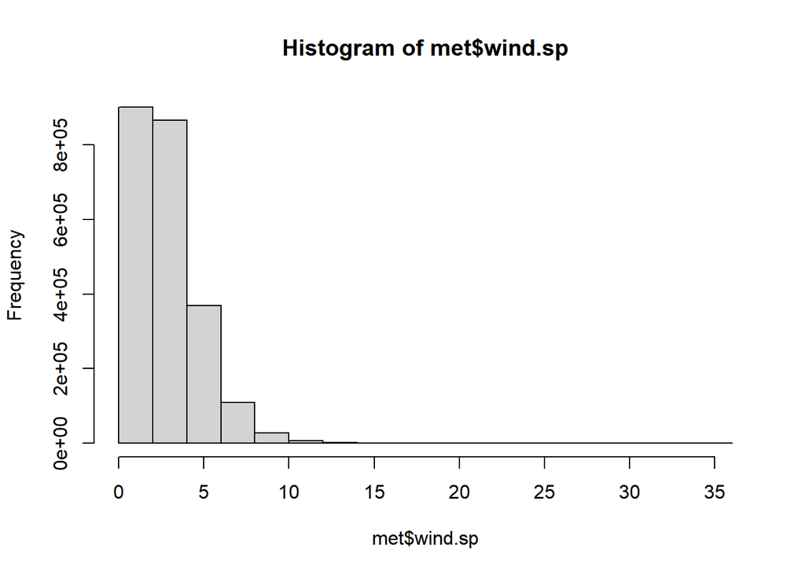

```r
hist(met$wind.sp)
```

```r
library(leaflet)
leaflet(elev1) %>%
  addProviderTiles('OpenStreetMap') %>%
  addCircles(lat=~lat,lng=~lon, opacity=1, fillOpacity=1, radius=100)
```

[interactive chart not shown]

```r
library(lubridate)
elev1$date <- with(elev1, ymd_h(paste(year, month, day, hour, sep= ' ')))
summary(elev1$date)
```

```
                      Min.                    1st Qu.
"2019-08-01 00:00:00.0000" "2019-08-08 11:00:00.0000"
                    Median                       Mean
"2019-08-16 22:00:00.0000" "2019-08-16 14:09:56.8823"
                   3rd Qu.                       Max.
"2019-08-24 11:00:00.0000" "2019-08-31 22:00:00.0000"
```

```r
elev1 <- elev1[order(elev1$date), ]
head(elev1)
```

```
   USAFID  WBAN  year month   day  hour   min   lat      lon  elev wind.dir
    <int> <int> <int> <int> <int> <int> <int> <num>    <num> <int>    <int>
1: 720385   419  2019     8     1     0    36  39.8 -105.766  4113      170
2: 720385   419  2019     8     1     0    54  39.8 -105.766  4113      100
3: 720385   419  2019     8     1     1    12  39.8 -105.766  4113       90
4: 720385   419  2019     8     1     1    35  39.8 -105.766  4113      110
5: 720385   419  2019     8     1     1    53  39.8 -105.766  4113      120
6: 720385   419  2019     8     1     2    12  39.8 -105.766  4113      120
   wind.dir.qc wind.type.code wind.sp wind.sp.qc ceiling.ht ceiling.ht.qc
        <char>         <char>   <num>     <char>      <int>         <int>
1:           5              N     8.8          5       1372             5
2:           5              N     2.6          5       1372             5
3:           5              N     3.1          5       1981             5
4:           5              N     4.1          5       2134             5
5:           5              N     4.6          5       2134             5
```

[output cut: 25 more lines]

### Use the plot function to make line graphs of temperature vs. date and wind speed vs. date

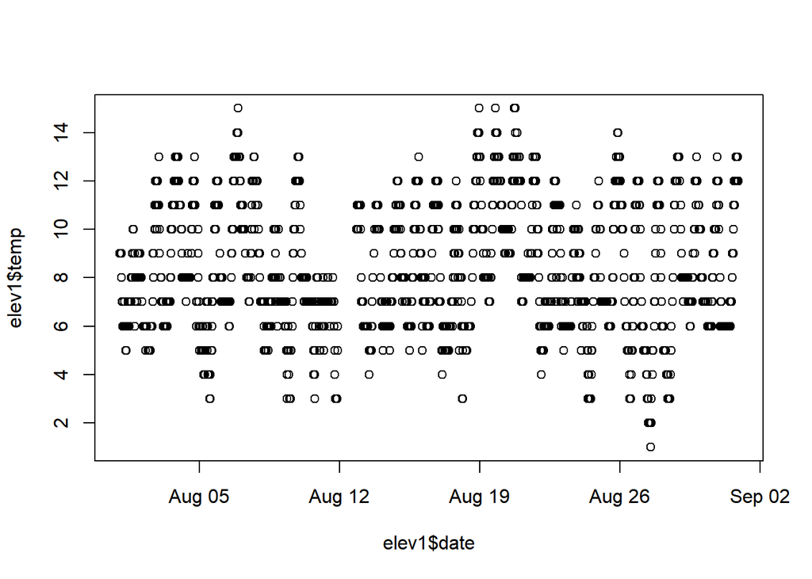

```r
plot(elev1$date, elev1$temp)
```

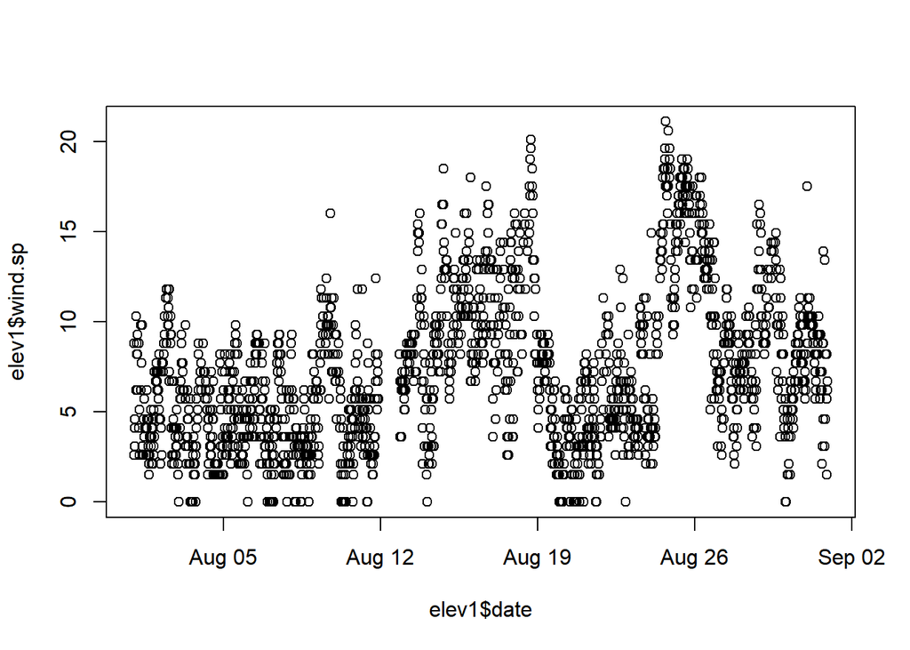

```r
plot(elev1$date, elev1$wind.sp)
```

From the temperature vs. date plot, we can see that temperatures fluctuated throughout the month with a few days of high temperatures from August 19-21. We see that there were also fluctuations in wind speed throughout August, with a highs between August 12 and 19, lows from August 19-24, and highs again between August 25-27.

## 8. Ask Questions

Why is some data inputted incorrectly? Do higher latitude locations have lower temperatures?

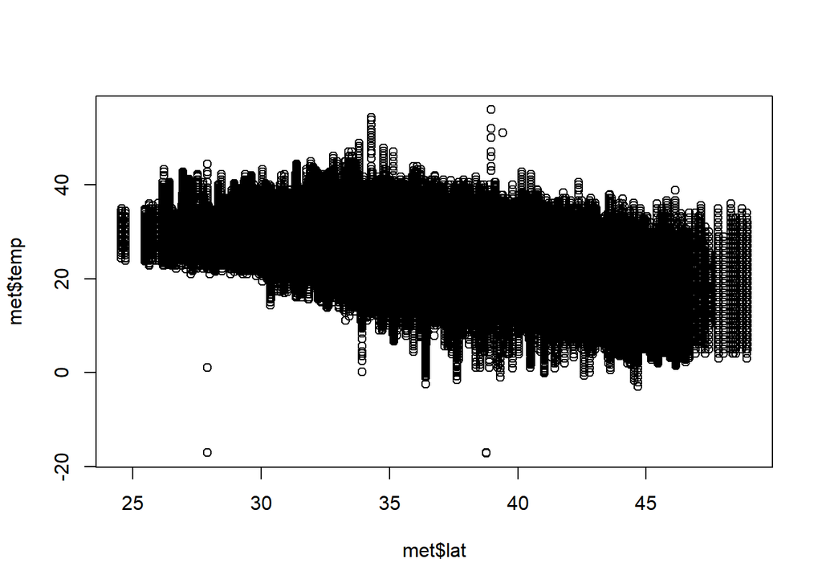

```r
plot(met$lat, met$temp)
```

Yes, higher latitudes have more variation in their temperatures and have a lower average temperature.